# Final Project

UBC Key Capabilities in Data Science

Introduction to Machine Learning - April 09 - May 27, 2024

Noriko Kono

#### **Introduction**

I am working on a project to develop machine learning models to predict the fat content levels in cheese products. I acknowledged that the data were obtained from Kaggle and followed an Open Government Licence (Canada).

The main question I seek to address through this project is: "Can the model accurately predict whether a cheese product has a higher or lower fat content based on the given data?" This question falls within the realm of supervised machine learning, specifically classification, as our target variable "FatLevel" is categorical, with boolean values representing "higher fat" and "lower fat".

I am adhering to the dataset description provided per my superiors' guidelines. The dataset description will be attached below for reference.

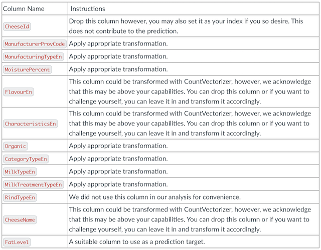

```python
import numpy as np
import pandas as pd
from sklearn.dummy import DummyClassifier, DummyRegressor
from sklearn.model_selection import train_test_split, cross_validate, RandomizedSearchCV
from sklearn.preprocessing import OneHotEncoder, StandardScaler, OrdinalEncoder
from sklearn.impute import SimpleImputer
from sklearn.compose import ColumnTransformer, make_column_transformer
from sklearn.pipeline import Pipeline, make_pipeline
from sklearn.svm import SVC
from sklearn.feature_extraction.text import CountVectorizer
from sklearn.metrics import ConfusionMatrixDisplay
from sklearn.metrics import classification_report
from sklearn.ensemble import RandomForestRegressor, RandomForestClassifier
from sklearn.preprocessing import (
    FunctionTransformer,
    Normalizer,
    OneHotEncoder,
    StandardScaler,
    normalize,
    scale)
from sklearn.metrics import make_scorer, f1_score, recall_score, precision_score, accuracy_score
from sklearn.model_selection import GridSearchCV
import altair as alt
from sklearn.tree import DecisionTreeClassifier
from sklearn.neighbors import KNeighborsClassifier, KNeighborsRegressor
from sklearn.feature_extraction.text import CountVectorizer
```

#### **Exploratory Data Analysis (EDA)**

```python
cheese_df = pd.read_csv("data/cheese_data.csv")
cheese_df.head()
```

|  | CheeseId | ManufacturerProvCode | ManufacturingTypeEn | MoisturePercent | FlavourEn | CharacteristicsEn | Organic | CategoryTypeEn | MilkTypeEn | MilkTreatmentTypeEn | RindTypeEn | CheeseName | FatLevel |
| --- | --- | --- | --- | --- | --- | --- | --- | --- | --- | --- | --- | --- | --- |
| 0 | 228 | NB | Farmstead | 47.0 | Sharp, lactic | Uncooked | 0 | Firm Cheese | Ewe | Raw Milk | Washed Rind | Sieur de Duplessis (Le) | lower fat |
| 1 | 242 | NB | Farmstead | 47.9 | Sharp, lactic, lightly caramelized | Uncooked | 0 | Semi-soft Cheese | Cow | Raw Milk | Washed Rind | Tomme Le Champ Doré | lower fat |
| 2 | 301 | ON | Industrial | 54.0 | Mild, tangy, and fruity | Pressed and cooked cheese, pasta filata, inter... | 0 | Firm Cheese | Cow | Pasteurized | NaN | Provolone Sette Fette (Tre-Stelle) | lower fat |
| 3 | 303 | NB | Farmstead | 47.0 | Sharp with fruity notes and a hint of wild honey | NaN | 0 | Veined Cheeses | Cow | Raw Milk | NaN | Geai Bleu (Le) | lower fat |
| 4 | 319 | NB | Farmstead | 49.4 | Softer taste | NaN | 1 | Semi-soft Cheese | Cow | Raw Milk | Washed Rind | Gamin (Le) | lower fat |

```python
cheese_df.info()
```

```
<class 'pandas.core.frame.DataFrame'>
RangeIndex: 1042 entries, 0 to 1041
Data columns (total 13 columns):
 #   Column                Non-Null Count  Dtype
---  ------                --------------  -----
 0   CheeseId              1042 non-null   int64
 1   ManufacturerProvCode  1042 non-null   object
 2   ManufacturingTypeEn   1042 non-null   object
 3   MoisturePercent       1028 non-null   float64
 4   FlavourEn             801 non-null    object
 5   CharacteristicsEn     643 non-null    object
 6   Organic               1042 non-null   int64
 7   CategoryTypeEn        1019 non-null   object
 8   MilkTypeEn            1041 non-null   object
 9   MilkTreatmentTypeEn   977 non-null    object
 10  RindTypeEn            721 non-null    object
 11  CheeseName            1042 non-null   object
 12  FatLevel              1042 non-null   object
dtypes: float64(1), int64(2), object(10)
memory usage: 106.0+ KB
```

```python
cheese_df.shape
```

```
(1042, 13)
```

**Sprit the data into the train and test sets**

```python
train_df, test_df = train_test_split(cheese_df, test_size=0.2, random_state=111)

X_train_big = train_df.drop(columns=["CheeseId", "FlavourEn", "CharacteristicsEn", "RindTypeEn", "CheeseName", "FatLevel"])
y_train_big = train_df["FatLevel"]

X_test = test_df.drop(columns=["CheeseId", "FlavourEn", "CharacteristicsEn", "RindTypeEn", "CheeseName", "FatLevel"])
y_test = test_df["FatLevel"]
```

From Module 3:

> Train/validation/test split
> - Train: Used to fit our models.
> - Validation: Used to assess our model during model tuning.
> - Test: Unseen data used for a final assessment.

```python
X_train, X_valid, y_train, y_valid = train_test_split(X_train_big, y_train_big, test_size=0.25, random_state=0)
```

```python
train_df.head(2)
```

|  | CheeseId | ManufacturerProvCode | ManufacturingTypeEn | MoisturePercent | FlavourEn | CharacteristicsEn | Organic | CategoryTypeEn | MilkTypeEn | MilkTreatmentTypeEn | RindTypeEn | CheeseName | FatLevel |
| --- | --- | --- | --- | --- | --- | --- | --- | --- | --- | --- | --- | --- | --- |
| 980 | 2306 | QC | Farmstead | 43.0 | NaN | NaN | 0 | Fresh Cheese | Ewe | Pasteurized | No Rind | Fromage Frais | lower fat |
| 361 | 1385 | QC | Industrial | 43.0 | Mild, hazelnut flavour, slightly acidulous | Smooth with small holes, no rind | 0 | Firm Cheese | Cow | Pasteurized | NaN | Bergeron Classique | lower fat |

```python
test_df.head(2)
```

|  | CheeseId | ManufacturerProvCode | ManufacturingTypeEn | MoisturePercent | FlavourEn | CharacteristicsEn | Organic | CategoryTypeEn | MilkTypeEn | MilkTreatmentTypeEn | RindTypeEn | CheeseName | FatLevel |
| --- | --- | --- | --- | --- | --- | --- | --- | --- | --- | --- | --- | --- | --- |
| 524 | 1552 | QC | Artisan | 40.0 | Very mild. Curds are aslo available BBQ seasoned | Daily fresh, withe cheese curds, twist or blocks. | 0 | Firm Cheese | Cow | Pasteurized | No Rind | Cheddar frais du jour (Fromagerie Perron) | higher fat |
| 707 | 1776 | QC | Industrial | 57.0 | Mild and salty | Compact, unripened | 0 | Soft Cheese | Cow | Pasteurized | No Rind | Akawie (Fromagerie Polyethnique) | lower fat |

```python
X_train.info()
```

```
<class 'pandas.core.frame.DataFrame'>
Int64Index: 624 entries, 798 to 84
Data columns (total 7 columns):
 #   Column                Non-Null Count  Dtype
---  ------                --------------  -----
 0   ManufacturerProvCode  624 non-null    object
 1   ManufacturingTypeEn   624 non-null    object
 2   MoisturePercent       616 non-null    float64
 3   Organic               624 non-null    int64
 4   CategoryTypeEn        609 non-null    object
 5   MilkTypeEn            623 non-null    object
 6   MilkTreatmentTypeEn   587 non-null    object
dtypes: float64(1), int64(1), object(5)
memory usage: 39.0+ KB
```

Most of the columns are categorical, and four columns contain missing values. I need to transform the categorical features into numeric ones and handle missing values.

```python
X_train.describe(include="all", percentiles=[])
```

|  | ManufacturerProvCode | ManufacturingTypeEn | MoisturePercent | Organic | CategoryTypeEn | MilkTypeEn | MilkTreatmentTypeEn |
| --- | --- | --- | --- | --- | --- | --- | --- |
| count | 624 | 624 | 616.000000 | 624.000000 | 609 | 623 | 587 |
| unique | 9 | 3 | NaN | NaN | 6 | 8 | 3 |
| top | QC | Industrial | NaN | NaN | Firm Cheese | Cow | Pasteurized |
| freq | 477 | 266 | NaN | NaN | 211 | 447 | 476 |
| mean | NaN | NaN | 47.123539 | 0.088141 | NaN | NaN | NaN |
| std | NaN | NaN | 9.472985 | 0.283727 | NaN | NaN | NaN |
| min | NaN | NaN | 12.000000 | 0.000000 | NaN | NaN | NaN |
| 50% | NaN | NaN | 46.000000 | 0.000000 | NaN | NaN | NaN |
| max | NaN | NaN | 83.000000 | 1.000000 | NaN | NaN | NaN |

```python
X_train.isnull().sum()
```

```
ManufacturerProvCode     0
ManufacturingTypeEn      0
MoisturePercent          8
Organic                  0
CategoryTypeEn          15
MilkTypeEn               1
MilkTreatmentTypeEn     37
dtype: int64
```

```python
y_train.describe
```

```
<bound method NDFrame.describe of 798     higher fat
194     higher fat
115      lower fat
995     higher fat
44      higher fat
           ...
160     higher fat
1029    higher fat
883      lower fat
811     higher fat
84      higher fat
Name: FatLevel, Length: 624, dtype: object>
```

> There are two kinds of binary classification problems:
> 1. Distinguishing between two classes
> 2. Spotting a class (fraud transaction, spam, disease)

The above description is from the Module 7 lecture video. The project involves solving a binary classification problem. I will proceed to distinguish between two classes: high and low fat contents.

```python
y_train.value_counts()
```

```
lower fat     415
higher fat    209
Name: FatLevel, dtype: int64
```

Modele:7:

> Addressing class imbalance

> A very important question to ask yourself: “Why do I have a class imbalance?”
> - Is it because one class is much rarer than the other?
> - Is it because of my data collection methods?

> But, if you answer “no” to both of these, it may be fine to just ignore the class imbalance.

Although I observe an imbalance in the class distribution, I will disregard it under the assumption that the answers to both questions are "no." However, I will utilize the hyperparameter class_weight="balanced", which is recommended when dealing with imbalanced classes for some models.

```python
y_train.isnull().sum()
```

```
0
```

**Visualizations**

```python
fat_level_plot = alt.Chart(train_df).mark_circle(size=60, opacity=0.3
 ).encode(
    x=alt.X('CheeseId', title='Cheese ID', scale=alt.Scale(zero=False)),
    y=alt.Y('FatLevel:N', title='Fat Level'),
    color=alt.Color('FatLevel', legend=alt.Legend(title="Fat Level")),
    tooltip=['CheeseId', 'FatLevel']
).properties(
    title={
      "text": ['Fat Level in Train Data'],
      "subtitle": ['A scatter plot showing the fat level for each cheese ID.'],
      "color": "black",
      "subtitleColor": "gray"
    },
    height=150,
    width=800
).interactive()

fat_level_plot
```

[interactive chart not shown]

```python
train_df["FatLevel"].value_counts(normalize=True)
```

```
lower fat     0.660264
higher fat    0.339736
Name: FatLevel, dtype: float64
```

```python
fat_level_prop = alt.Chart(train_df).mark_bar().encode(
    x='count()',
    y='FatLevel',
    color='FatLevel'
).properties(
    title='Fat Level Counts in Train Data',
    height=100
)

fat_level_prop
```

[interactive chart not shown]

```python
fat_level_prop_1 = alt.Chart(train_df).mark_bar().encode(
    x='ManufacturerProvCode:N',
    y='count()',
    color='FatLevel'
).properties(
    title='Fat Level in ManufacturerProvCode',
    height=100
)
```

```python
fat_level_prop_2 = alt.Chart(train_df).mark_bar().encode(
    x='ManufacturingTypeEn:N',
    y='count()',
    color='FatLevel'
).properties(
    title='Fat Level in ManufacturingTypeEn',
    height=100
)
```

```python
fat_level_prop_3 = alt.Chart(train_df).mark_bar().encode(
    x='MoisturePercent:N',
    y='count()',
    color='FatLevel'
).properties(
    title='MoisturePercent',
    height=100,
    width=1000
)
```

```python
fat_level_prop_4 = alt.Chart(train_df).mark_bar().encode(
    x='Organic:N',
    y='count()',
    color='FatLevel'
).properties(
    title='Fat Level in Organic',
    height=100
)
```

```python
fat_level_prop_5 = alt.Chart(train_df).mark_bar().encode(
    x='CategoryTypeEn:N',
    y='count()',
    color='FatLevel'
).properties(
    title='Fat Level in CategoryTypeEn',
    height=100
)
```

```python
fat_level_prop_6 = alt.Chart(train_df).mark_bar().encode(
    x='MilkTypeEn:N',
    y='count()',
    color='FatLevel'
).properties(
    title='Fat Level in MilkTypeEn',
    height=100
)
```

```python
fat_level_prop_7 = alt.Chart(train_df).mark_bar().encode(
    x='MilkTreatmentTypeEn:N',
    y='count()',
    color='FatLevel'
).properties(
    title='Fat Level in MilkTreatmentTypeEn',
    height=100
)
```

```python
fat_level_prop_1 | fat_level_prop_2
```

[interactive chart not shown]

```python
fat_level_prop_3
```

[interactive chart not shown]

```python
fat_level_prop_4 | fat_level_prop_5 | fat_level_prop_6 | fat_level_prop_7
```

[interactive chart not shown]

I will assess the models using metrics such as accuracy, precision, recall, f1 score, and the Confusion Matrix. These metrics were introduced in this program and I understand that they are widely accepted standards in the field.

**Identify different types of features**

**`Numeric Features`**

```python
train_df["MoisturePercent"].unique()
```

```
array([43. , 34. , 42. , 69. , 35. , 39. , 46. , 50. , 36. , 44. , 55. ,
        nan, 74. , 57. , 40. , 52. , 45. , 58. , 56. , 37. , 65. , 54. ,
       41. , 33. , 60. , 38. , 63. , 48. , 68. , 31. , 62. , 27. , 49. ,
       47. , 30. , 78. , 20. , 72. , 31.5, 32. , 53. , 70. , 80. , 29. ,
       47.9, 76. , 40.3, 26. , 49.4, 51.7, 59. , 64. , 61. , 83. , 42.8,
       67. , 12. , 17. , 22. , 23. , 21. , 51. , 42.6, 75. , 24. , 88. ])
```

**`Categorical Features`**

```python
train_df["ManufacturerProvCode"].unique()
```

```
array(['QC', 'ON', 'BC', 'NS', 'MB', 'PE', 'AB', 'NB', 'SK', 'NL'],
      dtype=object)
```

```python
train_df["ManufacturerProvCode"].value_counts()
```

```
QC    637
ON     92
BC     51
NB     21
AB     12
NS      9
MB      7
PE      2
SK      1
NL      1
Name: ManufacturerProvCode, dtype: int64
```

```python
train_df["ManufacturerProvCode"].value_counts(normalize=True)
```

```
QC    0.764706
ON    0.110444
BC    0.061224
NB    0.025210
AB    0.014406
NS    0.010804
MB    0.008403
PE    0.002401
SK    0.001200
NL    0.001200
Name: ManufacturerProvCode, dtype: float64
```

```python
train_df["ManufacturingTypeEn"].unique()
```

```
array(['Farmstead', 'Industrial', 'Artisan'], dtype=object)
```

```python
train_df["CategoryTypeEn"].unique()
```

```
array(['Fresh Cheese', 'Firm Cheese', 'Semi-soft Cheese', 'Soft Cheese',
       'Hard Cheese', nan, 'Veined Cheeses'], dtype=object)
```

```python
train_df["MilkTypeEn"].unique()
```

```
array(['Ewe', 'Cow', 'Goat', 'Cow and Goat', 'Ewe and Cow',
       'Cow, Goat and Ewe', nan, 'Ewe and Goat', 'Buffalo Cow'],
      dtype=object)
```

```python
train_df["MilkTreatmentTypeEn"].unique()
```

```
array(['Pasteurized', 'Raw Milk', 'Thermised', nan], dtype=object)
```

**`Binary Features`**

```python
train_df["Organic"].unique()
```

```
array([0, 1])
```

**Start with Baseline** Without Preprocessing

```python
# Baseline
dummy = DummyClassifier(strategy="most_frequent")
pd.DataFrame(cross_validate(dummy, X_train, y_train, return_train_score=True)).mean()
```

```
fit_time       0.013315
score_time     0.000860
test_score     0.665071
train_score    0.665065
dtype: float64
```

```python
dummy = DummyClassifier(strategy="stratified")

# Helped by Copilot
# The pos_label parameter is used in binary classification tasks to specify which of the two classes is the positive class.
# In your case, it seems like your classes are ‘higher fat’ and ‘lower fat’, not 0 and 1.
scoring = {
    "accuracy": "accuracy",
    "f1": make_scorer(f1_score, pos_label='higher fat'),
    "recall": make_scorer(recall_score, pos_label='higher fat'),
    "precision": make_scorer(precision_score, pos_label='higher fat')
}
cv_results = cross_validate(dummy, X_train, y_train, cv=5, scoring=scoring, return_train_score=True)
dummy_scores = pd.DataFrame(cv_results)
dummy_scores
```

|  | fit_time | score_time | test_accuracy | train_accuracy | test_f1 | train_f1 | test_recall | train_recall | test_precision | train_precision |
| --- | --- | --- | --- | --- | --- | --- | --- | --- | --- | --- |
| 0 | 0.002138 | 0.007498 | 0.536000 | 0.551102 | 0.355556 | 0.321212 | 0.380952 | 0.317365 | 0.333333 | 0.325153 |
| 1 | 0.001894 | 0.007797 | 0.600000 | 0.559118 | 0.418605 | 0.312500 | 0.428571 | 0.299401 | 0.409091 | 0.326797 |
| 2 | 0.001920 | 0.007010 | 0.568000 | 0.589178 | 0.270270 | 0.369231 | 0.238095 | 0.359281 | 0.312500 | 0.379747 |
| 3 | 0.001724 | 0.007046 | 0.568000 | 0.585170 | 0.357143 | 0.359133 | 0.357143 | 0.347305 | 0.357143 | 0.371795 |
| 4 | 0.002248 | 0.007962 | 0.524194 | 0.542000 | 0.351648 | 0.312312 | 0.390244 | 0.309524 | 0.320000 | 0.315152 |

I was so confused. As a novice, I didn’t understand why DummyClassifier accepted the categorical features without preprocessing. I have spent many hours trying to figure out why. I thought the models only utilized the numerical values. AI provided me with the following explanation

[figure not shown]

Since the official scikit-learn website stated, "Do not use it for real problems," I assume this is not a concern. Besides, it only returned the poor results.

> DummyClassifier is a classifier that makes predictions using simple rules.

> This classifier is useful as a simple baseline to compare with other (real) classifiers. Do not use it for real problems.

Eventually, I found the answer.

#### **Preprocessing**

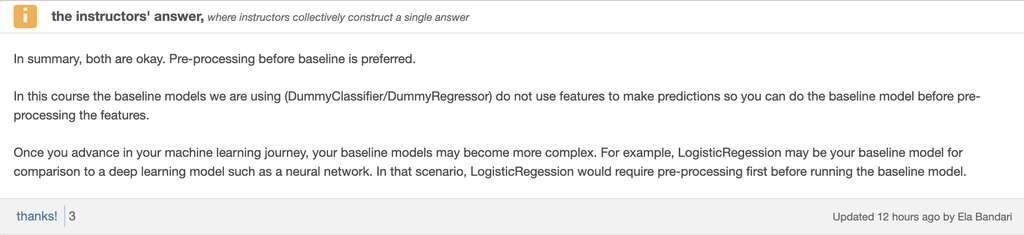

> Preprocessing: Transforming input data into a format a machine learning model can use and understand.

From Module 6

> Do we need to preprocess categorical values in the target column? Generally, there is no need for this when doing classification. sklearn is fine with categorical labels (y-values) for classification problems.

Briefly justify my choices

```
I concluded as below. I observed many methods to investigate each column. I wondered if there were any ordinal features, but I didn't find it.
```

Split the numeric, categorical and binary features

```python
numeric_features = ["MoisturePercent"]
```

```python
categorical_features = ["ManufacturerProvCode", "ManufacturingTypeEn", "CategoryTypeEn",
                        "MilkTypeEn", "MilkTreatmentTypeEn"]
```

```python
binary_features = ["Organic"]
```

make_pipeline

```python
numeric_transformer = make_pipeline(
    SimpleImputer(strategy="median"),
    StandardScaler()
)

categorical_transformer = make_pipeline(
    SimpleImputer(strategy="constant", fill_value="missing"),
    OneHotEncoder(handle_unknown="ignore")
)

binary_transformer = make_pipeline(
    SimpleImputer(strategy="constant"),
    OneHotEncoder(drop="if_binary", dtype=int)
)
```

make_column_transformer

```python
preprocessor = make_column_transformer(
            (numeric_transformer, numeric_features),
            (categorical_transformer, categorical_features),
            (binary_transformer, binary_features),
            remainder="passthrough"
)
```

#### **Methods & Results**

> 3 types of scores:
> - `Training score`: The score that our model gets on the same data that it was trained on. (seen data - training data)
> - `Validation score`: The mean validation score from cross-validation).
> - `Test score`: This is the score from the data that we locked away.

**Start with Baseline** With Preprocessing

```python
dummy_pipe = make_pipeline(preprocessor, DummyClassifier(strategy="most_frequent"))
dummy_pipe.fit(X_train, y_train)
cv_results = cross_validate(dummy_pipe, X_train, y_train, return_train_score=True)
pd.DataFrame(cv_results).mean()
```

```
fit_time       0.035463
score_time     0.017230
test_score     0.665071
train_score    0.665065
dtype: float64
```

```python
dummy_pipe = make_pipeline(preprocessor, DummyClassifier(strategy="stratified"))

# Helped by Copilot
# The pos_label parameter is used in binary classification tasks to specify which of the two classes is the positive class.
# In your case, it seems like your classes are ‘higher fat’ and ‘lower fat’, not 0 and 1.
scoring = {
    "accuracy": "accuracy",
    "precision": make_scorer(precision_score, pos_label='higher fat'),
    "recall": make_scorer(recall_score, pos_label='higher fat'),
    "f1": make_scorer(f1_score, pos_label='higher fat'),
}
cv_results = cross_validate(dummy_pipe, X_train, y_train, cv=5, scoring=scoring, return_train_score=True)
dummy_scores = pd.DataFrame(cv_results)
dummy_scores.mean()
```

```
fit_time           0.028246
score_time         0.024834
test_accuracy      0.586619
train_accuracy     0.565701
test_precision     0.375412
train_precision    0.348996
test_recall        0.359233
train_recall       0.340861
test_f1            0.367001
train_f1           0.344636
dtype: float64
```

Processing does not contribute to the improvement of the DummyClassifier’s performance.

**Automated Hyperparameter Optimization**

```python
scoring = {
    "accuracy": "accuracy",
    "precision": make_scorer(precision_score, pos_label='higher fat'),
    "recall": make_scorer(recall_score, pos_label='higher fat'),
    "f1": make_scorer(f1_score, pos_label='higher fat'),
}
```

**`KNeighborsClassifier`**

```python
pipeline = Pipeline([
    ('preprocessor', preprocessor),
    ('knn', KNeighborsClassifier())
])

param_grid = {
    "knn__n_neighbors" : [1, 5, 10, 20, 30, 40, 50],
    "knn__weights" : ['uniform', 'distance']
}

grid_search = GridSearchCV(pipeline, param_grid, cv=5, verbose=1, n_jobs=-1)
grid_search.fit(X_train, y_train)

grid_scores = pd.DataFrame(grid_search.cv_results_)
grid_scores.mean()
```

```
Fitting 5 folds for each of 14 candidates, totalling 70 fits
```

```
mean_fit_time              0.029034
std_fit_time               0.003147
mean_score_time            0.022631
std_score_time             0.003222
param_knn__n_neighbors    22.285714
split0_test_score          0.793143
split1_test_score          0.801714
split2_test_score          0.793714
split3_test_score          0.817714
split4_test_score          0.784562
mean_test_score            0.798170
std_test_score             0.024497
rank_test_score            7.428571
dtype: float64
```

```python
best_hyperparams = grid_search.best_params_
print(best_hyperparams)

test_score = grid_search.score(X_test, y_test)
print(test_score)
```

```
{'knn__n_neighbors': 50, 'knn__weights': 'distance'}
0.861244019138756
```

We have imbalanced data; therefore, I implemented the hyperparameter class_weight="balanced".

**`SVC`**

```python
pipe = make_pipeline(preprocessor, SVC(class_weight="balanced"))

param_grid = {
    "svc__gamma": [0.1, 1.0, 10, 100],
    "svc__C": [0.1, 1.0, 10, 100]
}

grid_search = GridSearchCV(pipe, param_grid, cv=5, return_train_score=True, scoring='accuracy', refit=True)
grid_search.fit(X_train, y_train)
multi_scores = pd.DataFrame(grid_search.cv_results_)
multi_scores.mean()
```

```
mean_fit_time          0.053355
std_fit_time           0.015930
mean_score_time        0.018154
std_score_time         0.002540
param_svc__C          27.775000
param_svc__gamma      27.775000
split0_test_score      0.731000
split1_test_score      0.751500
split2_test_score      0.759000
split3_test_score      0.778500
split4_test_score      0.696069
mean_test_score        0.743214
std_test_score         0.033558
rank_test_score        8.500000
split0_train_score     0.864354
split1_train_score     0.862851
split2_train_score     0.868236
split3_train_score     0.864354
split4_train_score     0.869875
mean_train_score       0.865934
std_train_score        0.008048
dtype: float64
```

**`RandomForestClassifier`**

pipe = make_pipeline(preprocessor, RandomForestClassifier(class_weight="balanced", random_state=77))

```python
pipe = make_pipeline(preprocessor, RandomForestClassifier(class_weight="balanced", random_state=77))
pipe.fit(X_train, y_train);

cv_results = cross_validate(pipe, X_train, y_train, cv=5, scoring=scoring, return_train_score=True)
scores = pd.DataFrame(cv_results)
scores.mean()
```

```
fit_time           0.304647
score_time         0.037947
test_accuracy      0.801290
train_accuracy     0.952726
test_precision     0.707939
train_precision    0.896336
test_recall        0.703136
train_recall       0.971300
test_f1            0.700616
train_f1           0.932294
dtype: float64
```

**Randomized hyperparameter optimization**

```python
# Randomized hyperparameter optimization
param_grid = {
    "randomforestclassifier__max_depth": range(1,151,10)
}

depth_search = RandomizedSearchCV(pipe, param_grid, n_jobs=-1, cv=5,
                                  return_train_score=True, n_iter=5,
                                  random_state=77, verbose=3)

depth_search.fit(X_train, y_train)
```

```
Fitting 5 folds for each of 5 candidates, totalling 25 fits
[CV 1/5] END randomforestclassifier__max_depth=141;, score=(train=0.958, test=0.792) total time=   0.4s
[CV 2/5] END randomforestclassifier__max_depth=141;, score=(train=0.946, test=0.816) total time=   0.4s
[CV 3/5] END randomforestclassifier__max_depth=141;, score=(train=0.956, test=0.752) total time=   0.3s
[CV 4/5] END randomforestclassifier__max_depth=141;, score=(train=0.956, test=0.840) total time=   0.3s
[CV 5/5] END randomforestclassifier__max_depth=141;, score=(train=0.948, test=0.806) total time=   0.3s
[CV 1/5] END randomforestclassifier__max_depth=61;, score=(train=0.958, test=0.792) total time=   0.3s
[CV 2/5] END randomforestclassifier__max_depth=61;, score=(train=0.946, test=0.816) total time=   0.3s
[CV 3/5] END randomforestclassifier__max_depth=61;, score=(train=0.956, test=0.752) total time=   0.4s
[CV 4/5] END randomforestclassifier__max_depth=61;, score=(train=0.956, test=0.840) total time=   0.3s
[CV 5/5] END randomforestclassifier__max_depth=61;, score=(train=0.948, test=0.806) total time=   0.4s
[CV 1/5] END randomforestclassifier__max_depth=21;, score=(train=0.958, test=0.792) total time=   0.3s
[CV 2/5] END randomforestclassifier__max_depth=21;, score=(train=0.946, test=0.816) total time=   0.3s
[CV 3/5] END randomforestclassifier__max_depth=21;, score=(train=0.956, test=0.752) total time=   0.3s
[CV 4/5] END randomforestclassifier__max_depth=21;, score=(train=0.956, test=0.840) total time=   0.3s
[CV 5/5] END randomforestclassifier__max_depth=21;, score=(train=0.948, test=0.806) total time=   0.3s
[CV 1/5] END randomforestclassifier__max_depth=91;, score=(train=0.958, test=0.792) total time=   0.3s
[CV 2/5] END randomforestclassifier__max_depth=91;, score=(train=0.946, test=0.816) total time=   0.3s
[CV 3/5] END randomforestclassifier__max_depth=91;, score=(train=0.956, test=0.752) total time=   0.3s
[CV 4/5] END randomforestclassifier__max_depth=91;, score=(train=0.956, test=0.840) total time=   0.3s
[CV 5/5] END randomforestclassifier__max_depth=91;, score=(train=0.948, test=0.806) total time=   0.3s
[CV 1/5] END randomforestclassifier__max_depth=31;, score=(train=0.958, test=0.792) total time=   0.4s
[CV 2/5] END randomforestclassifier__max_depth=31;, score=(train=0.946, test=0.816) total time=   0.3s
[CV 3/5] END randomforestclassifier__max_depth=31;, score=(train=0.956, test=0.752) total time=   0.3s
[CV 4/5] END randomforestclassifier__max_depth=31;, score=(train=0.956, test=0.840) total time=   0.3s
[CV 5/5] END randomforestclassifier__max_depth=31;, score=(train=0.948, test=0.806) total time=   0.3s
```

```
RandomizedSearchCV(cv=5,
                   estimator=Pipeline(steps=[('columntransformer',
                                              ColumnTransformer(remainder='passthrough',
                                                                transformers=[('pipeline-1',
                                                                               Pipeline(steps=[('simpleimputer',
                                                                                                SimpleImputer(strategy='median')),
                                                                                               ('standardscaler',
                                                                                                StandardScaler())]),
                                                                               ['MoisturePercent']),
                                                                              ('pipeline-2',
                                                                               Pipeline(steps=[('simpleimputer',
                                                                                                SimpleImputer(fill_value='missing',
                                                                                                              s...
                                                                                                SimpleImputer(strategy='constant')),
                                                                                               ('onehotencoder',
                                                                                                OneHotEncoder(drop='if_binary',
                                                                                                              dtype=<class 'int'>))]),
                                                                               ['Organic'])])),
                                             ('randomforestclassifier',
                                              RandomForestClassifier(class_weight='balanced',
                                                                     random_state=77))]),
                   n_iter=5, n_jobs=-1,
                   param_distributions={'randomforestclassifier__max_depth': range(1, 151, 10)},
                   random_state=77, return_train_score=True, verbose=3)
```

```python
cv_results = depth_search.cv_results_
grid_results = pd.DataFrame({
    'mean_test_score': cv_results['mean_test_score'],
    'param_randomforestclassifier__max_depth': cv_results['param_randomforestclassifier__max_depth'],
    'mean_fit_time': cv_results['mean_fit_time'],
    'rank_test_score': cv_results['rank_test_score']
})

grid_results = grid_results.sort_values(by='rank_test_score')
grid_results
```

|  | mean_test_score | param_randomforestclassifier__max_depth | mean_fit_time | rank_test_score |
| --- | --- | --- | --- | --- |
| 0 | 0.80129 | 141 | 0.313872 | 1 |
| 1 | 0.80129 | 61 | 0.315057 | 1 |
| 2 | 0.80129 | 21 | 0.299484 | 1 |
| 3 | 0.80129 | 91 | 0.304250 | 1 |
| 4 | 0.80129 | 31 | 0.304566 | 1 |

```python
best_depth = depth_search.best_params_['randomforestclassifier__max_depth']
print(f'The best parameter: {best_depth}')

best_depth_score = depth_search.best_score_
print(f'The best score: {best_depth_score}')

test_score = depth_search.score(X_test, y_test)
print(f'The test score: {test_score}')
```

```
The best parameter: 141
The best score: 0.8012903225806453
The test score: 0.8421052631578947
```

```python
depth_search.classes_
print(classification_report(y_test, depth_search.predict(X_test),
                            target_names=["higer fat", "lower fat"]))
```

```
              precision    recall  f1-score   support

   higer fat       0.78      0.79      0.78        75
   lower fat       0.88      0.87      0.88       134

    accuracy                           0.84       209
   macro avg       0.83      0.83      0.83       209
weighted avg       0.84      0.84      0.84       209
```

pipe = make_pipeline(preprocessor, RandomForestClassifier(class_weight="balanced", random_state=77, max_depth=141))

```python
pipe = make_pipeline(preprocessor, RandomForestClassifier(class_weight="balanced", random_state=77, max_depth=141))
pipe.fit(X_train, y_train);

cv_results = cross_validate(pipe, X_train, y_train, cv=5, scoring=scoring, return_train_score=True)
scores = pd.DataFrame(cv_results)
scores.mean()
```

```
fit_time           0.304439
score_time         0.038825
test_accuracy      0.801290
train_accuracy     0.952726
test_precision     0.707939
train_precision    0.896336
test_recall        0.703136
train_recall       0.971300
test_f1            0.700616
train_f1           0.932294
dtype: float64
```

```python
param_grid = {
    'randomforestclassifier__n_estimators': [100, 200, 300, 400, 500],
    'randomforestclassifier__min_samples_split': [2, 5, 10],
    'randomforestclassifier__min_samples_leaf': [1, 2, 4],
    'randomforestclassifier__max_features': ['auto', 'sqrt']
}

grid_search = RandomizedSearchCV(pipe, param_grid, n_jobs=-1, cv=5,
                                  return_train_score=True, n_iter=5,
                                  random_state=77, verbose=1)

grid_search.fit(X_train, y_train)
```

```
Fitting 5 folds for each of 5 candidates, totalling 25 fits
```

```
RandomizedSearchCV(cv=5,
                   estimator=Pipeline(steps=[('columntransformer',
                                              ColumnTransformer(remainder='passthrough',
                                                                transformers=[('pipeline-1',
                                                                               Pipeline(steps=[('simpleimputer',
                                                                                                SimpleImputer(strategy='median')),
                                                                                               ('standardscaler',
                                                                                                StandardScaler())]),
                                                                               ['MoisturePercent']),
                                                                              ('pipeline-2',
                                                                               Pipeline(steps=[('simpleimputer',
                                                                                                SimpleImputer(fill_value='missing',
                                                                                                              s...
                                              RandomForestClassifier(class_weight='balanced',
                                                                     max_depth=141,
                                                                     random_state=77))]),
                   n_iter=5, n_jobs=-1,
                   param_distributions={'randomforestclassifier__max_features': ['auto',
                                                                                 'sqrt'],
                                        'randomforestclassifier__min_samples_leaf': [1,
                                                                                     2,
                                                                                     4],
                                        'randomforestclassifier__min_samples_split': [2,
                                                                                      5,
                                                                                      10],
                                        'randomforestclassifier__n_estimators': [100,
                                                                                 200,
                                                                                 300,
                                                                                 400,
                                                                                 500]},
                   random_state=77, return_train_score=True, verbose=1)
```

```python
best_model = grid_search.best_estimator_
cv_results = cross_validate(best_model, X_train, y_train, scoring=scoring, return_train_score=True)
scores = pd.DataFrame(cv_results)
mean_scores = scores.mean()
mean_scores
```

```
fit_time           0.499142
score_time         0.053857
test_accuracy      0.831742
train_accuracy     0.899044
test_precision     0.734181
train_precision    0.830582
test_recall        0.779791
train_recall       0.878008
test_f1            0.753296
train_f1           0.853533
dtype: float64
```

```python
grid_search.classes_
print(classification_report(y_test, depth_search.predict(X_test),
                            target_names=["higer fat", "lower fat"]))
```

```
              precision    recall  f1-score   support

   higer fat       0.78      0.79      0.78        75
   lower fat       0.88      0.87      0.88       134

    accuracy                           0.84       209
   macro avg       0.83      0.83      0.83       209
weighted avg       0.84      0.84      0.84       209
```

```python
# Copilot suggestion to improve the model
from sklearn.model_selection import RandomizedSearchCV

param_dist = {
    'randomforestclassifier__n_estimators': [100, 200, 300],
    'randomforestclassifier__max_features': ['auto', 'sqrt', 'log2'],
    'randomforestclassifier__max_depth' : [80, 90, 100, 110],
    'randomforestclassifier__min_samples_split': [2, 5, 10],
    'randomforestclassifier__min_samples_leaf': [1, 2, 4],
}

rscv = RandomizedSearchCV(pipe, param_dist, n_jobs=1, cv=5, n_iter=10)

rscv.fit(X_train, y_train)
```

```
RandomizedSearchCV(cv=5,
                   estimator=Pipeline(steps=[('columntransformer',
                                              ColumnTransformer(remainder='passthrough',
                                                                transformers=[('pipeline-1',
                                                                               Pipeline(steps=[('simpleimputer',
                                                                                                SimpleImputer(strategy='median')),
                                                                                               ('standardscaler',
                                                                                                StandardScaler())]),
                                                                               ['MoisturePercent']),
                                                                              ('pipeline-2',
                                                                               Pipeline(steps=[('simpleimputer',
                                                                                                SimpleImputer(fill_value='missing',
                                                                                                              s...
                                              RandomForestClassifier(class_weight='balanced',
                                                                     max_depth=141,
                                                                     random_state=77))]),
                   n_jobs=1,
                   param_distributions={'randomforestclassifier__max_depth': [80,
                                                                              90,
                                                                              100,
                                                                              110],
                                        'randomforestclassifier__max_features': ['auto',
                                                                                 'sqrt',
                                                                                 'log2'],
                                        'randomforestclassifier__min_samples_leaf': [1,
                                                                                     2,
                                                                                     4],
                                        'randomforestclassifier__min_samples_split': [2,
                                                                                      5,
                                                                                      10],
                                        'randomforestclassifier__n_estimators': [100,
                                                                                 200,
                                                                                 300]})
```

```python
best_model = rscv.best_estimator_
cv_results = cross_validate(best_model, X_train, y_train, cv=5, scoring=scoring, return_train_score=True)
scores = pd.DataFrame(cv_results)
mean_scores = scores.mean()
mean_scores
```

```
fit_time           0.731776
score_time         0.067826
test_accuracy      0.833316
train_accuracy     0.902647
test_precision     0.731977
train_precision    0.830237
test_recall        0.794077
train_recall       0.892365
test_f1            0.759613
train_f1           0.860022
dtype: float64
```

```python
rscv.classes_
print(classification_report(y_test, depth_search.predict(X_test),
                            target_names=["higer fat", "lower fat"]))
```

```
              precision    recall  f1-score   support

   higer fat       0.78      0.79      0.78        75
   lower fat       0.88      0.87      0.88       134

    accuracy                           0.84       209
   macro avg       0.83      0.83      0.83       209
weighted avg       0.84      0.84      0.84       209
```

**The best search result**

```python
best_model = rscv.best_estimator_
best_model.fit(X_train, y_train)
```

```
Pipeline(steps=[('columntransformer',
                 ColumnTransformer(remainder='passthrough',
                                   transformers=[('pipeline-1',
                                                  Pipeline(steps=[('simpleimputer',
                                                                   SimpleImputer(strategy='median')),
                                                                  ('standardscaler',
                                                                   StandardScaler())]),
                                                  ['MoisturePercent']),
                                                 ('pipeline-2',
                                                  Pipeline(steps=[('simpleimputer',
                                                                   SimpleImputer(fill_value='missing',
                                                                                 strategy='constant')),
                                                                  ('onehotencod...
                                                   'MilkTreatmentTypeEn']),
                                                 ('pipeline-3',
                                                  Pipeline(steps=[('simpleimputer',
                                                                   SimpleImputer(strategy='constant')),
                                                                  ('onehotencoder',
                                                                   OneHotEncoder(drop='if_binary',
                                                                                 dtype=<class 'int'>))]),
                                                  ['Organic'])])),
                ('randomforestclassifier',
                 RandomForestClassifier(class_weight='balanced', max_depth=100,
                                        max_features='sqrt',
                                        min_samples_split=10, n_estimators=300,
                                        random_state=77))])
```

```python
best_model.score(X_test, y_test)
```

```
0.861244019138756
```

Ultimately, my model has attained a test score of 0.86, a training accuracy of 0.90 and a test accuracy of 0.83. In my humble assessment, these results are reasonably good.

**`Confusion Matrix`**

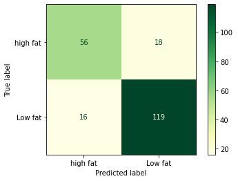

```python
from sklearn.metrics import  plot_confusion_matrix

plot_confusion_matrix(pipe, X_valid, y_valid, display_labels=["high fat", "Low fat"], values_format="d", cmap="YlGn");
```

**`confusion_matrix NumPy array`**

```python
from sklearn.metrics import confusion_matrix

predictions = pipe.predict(X_valid)
confusion_matrix(y_valid, predictions)
```

```
array([[ 56,  18],
       [ 16, 119]])
```

**`Precision, recall and f1-score`**

Three commonly used metrics recall, precision and f1 score, which are based on the confusion matrix.

$precision = \frac{\text{True Positives}}{\text{True Positives} + \text{False Positives}}$

$recall = \frac{\text{True Positives}}{\text{True Positives} + \text{False Negative}}$

$f1 = 2 \cdot \frac{\text{Precision} \cdot \text{Recall}}{\text{Precision} + \text{Recall}}$

```python
confusion_matrix(y_valid, predictions)
```

```
array([[ 56,  18],
       [ 16, 119]])
```

```python
TN, FP, FN, TP = confusion_matrix(y_valid, predictions).ravel()
```

```python
recall = TP / (TP + FN)
precision = TP / (TP + FP)
data = {}
data["accuracy"] = [(TP + TN) / (TN + FP + FN + TP)]
data["error"] = [(FP + FN) / (TN + FP + FN + TP)]
data["precision"] = [ TP / (TP + FP)]
data["recall"] = [TP / (TP + FN)]
data["f1 score"] = [(2 * precision * recall) / (precision + recall)]
measures_df = pd.DataFrame(data, index=['ourselves'])
measures_df
```

|  | accuracy | error | precision | recall | f1 score |
| --- | --- | --- | --- | --- | --- |
| ourselves | 0.837321 | 0.162679 | 0.868613 | 0.881481 | 0.875 |

```python
predicted_y = pipe.predict(X_valid)

precision = precision_score(y_valid, predicted_y, pos_label='higher fat').round(3)
print("precision: ", precision)

recall = recall_score(y_valid, predicted_y, pos_label='higher fat').round(3)
print("recall: ", recall)

f1 = f1_score(y_valid, predicted_y, pos_label='higher fat').round(3)
print("f1:", f1)

print(classification_report(y_valid, predicted_y, digits=3))
```

```
precision:  0.778
recall:  0.757
f1: 0.767
              precision    recall  f1-score   support

  higher fat      0.778     0.757     0.767        74
   lower fat      0.869     0.881     0.875       135

    accuracy                          0.837       209
   macro avg      0.823     0.819     0.821       209
weighted avg      0.836     0.837     0.837       209
```

```python
pipe.classes_
```

```
array(['higher fat', 'lower fat'], dtype=object)
```

```python
print(classification_report(y_valid, pipe.predict(X_valid)))
```

```
              precision    recall  f1-score   support

  higher fat       0.78      0.76      0.77        74
   lower fat       0.87      0.88      0.87       135

    accuracy                           0.84       209
   macro avg       0.82      0.82      0.82       209
weighted avg       0.84      0.84      0.84       209
```

**Feature importances**

```python
importances = pipe.named_steps['randomforestclassifier'].feature_importances_

print("Feature ranking:")

for f in range(X_train.shape[1]):
    print("%d. feature %d (%f)" % (f + 1, f, importances[f]))
```

```
Feature ranking:
1. feature 0 (0.514878)
2. feature 1 (0.005168)
3. feature 2 (0.014288)
4. feature 3 (0.004052)
5. feature 4 (0.004764)
6. feature 5 (0.004204)
7. feature 6 (0.016653)
```

```python
X_train.columns
```

```
Index(['ManufacturerProvCode', 'ManufacturingTypeEn', 'MoisturePercent',
       'Organic', 'CategoryTypeEn', 'MilkTypeEn', 'MilkTreatmentTypeEn'],
      dtype='object')
```

**Linear Regression**

I needed to change target values to binary.

```python
# Initialize the LabelEncoder
from sklearn.preprocessing import LabelEncoder

# Initialize the LabelEncoder
le = LabelEncoder()

# Fit label encoder and return encoded labels
y_train_binary = le.fit_transform(y_train)
```

```python
y_train_binary
```

[output not shown]

```python
from sklearn.linear_model import Ridge

rm_pipe = make_pipeline(preprocessor, Ridge())

param_dist = {
    'ridge__alpha': [0.1, 1, 10, 100, 1000, 10000]
}

grid_search = GridSearchCV(
    rm_pipe,
    param_dist,
    cv=5,
    n_jobs=-1
)

grid_search.fit(X_train, y_train_binary)
```

```
GridSearchCV(cv=5,
             estimator=Pipeline(steps=[('columntransformer',
                                        ColumnTransformer(remainder='passthrough',
                                                          transformers=[('pipeline-1',
                                                                         Pipeline(steps=[('simpleimputer',
                                                                                          SimpleImputer(strategy='median')),
                                                                                         ('standardscaler',
                                                                                          StandardScaler())]),
                                                                         ['MoisturePercent']),
                                                                        ('pipeline-2',
                                                                         Pipeline(steps=[('simpleimputer',
                                                                                          SimpleImputer(fill_value='missing',
                                                                                                        strateg...
                                                                         ['ManufacturerProvCode',
                                                                          'ManufacturingTypeEn',
                                                                          'CategoryTypeEn',
                                                                          'MilkTypeEn',
                                                                          'MilkTreatmentTypeEn']),
                                                                        ('pipeline-3',
                                                                         Pipeline(steps=[('simpleimputer',
                                                                                          SimpleImputer(strategy='constant')),
                                                                                         ('onehotencoder',
                                                                                          OneHotEncoder(drop='if_binary',
                                                                                                        dtype=<class 'int'>))]),
                                                                         ['Organic'])])),
                                       ('ridge', Ridge())]),
             n_jobs=-1,
             param_grid={'ridge__alpha': [0.1, 1, 10, 100, 1000, 10000]})
```

```python
best_alpha = grid_search.best_params_
print(best_alpha)
```

```
{'ridge__alpha': 10}
```

```python
best_score = grid_search.best_score_
print(best_score)
```

```
0.2617533611936226
```

**`Regression measurements`**

- mean squared error (MSE)
- R2
- root mean squared error (RMSE)
- MAPE

```python
from sklearn.metrics import make_scorer

# https://stackoverflow.com/questions/14861891/runtimewarning-invalid-value-encountered-in-divide
np.seterr(divide='ignore', invalid='ignore')

def mape(true, pred):

    # In this code, epsilon is a small constant added to avoid division by zero.
    epsilon = 1e-10  # small constant
    return 100.0 * np.mean(np.abs((pred - true) / (true + epsilon)))

mape_scorer = make_scorer(mape, greater_is_better=False)
```

```python
scoring_dict = {"neg_mean_squared_error": "neg_mean_squared_error",
                "neg_root_mean_squared_error": "neg_root_mean_squared_error",
                "neg_mean_absolute_error": "neg_mean_absolute_error",
                "r2": "r2",
                "mape_scorer": mape_scorer
               }
```

```python
regression_scores = pd.DataFrame(cross_validate(pipe, X_train, y_train_binary, return_train_score=True, scoring=scoring_dict))
regression_scores
```

|  | fit_time | score_time | test_neg_mean_squared_error | train_neg_mean_squared_error | test_neg_root_mean_squared_error | train_neg_root_mean_squared_error | test_neg_mean_absolute_error | train_neg_mean_absolute_error | test_r2 | train_r2 | test_mape_scorer | train_mape_scorer |
| --- | --- | --- | --- | --- | --- | --- | --- | --- | --- | --- | --- | --- |
| 0 | 0.321493 | 0.029620 | -0.208000 | -0.042084 | -0.456070 | -0.205144 | -0.208000 | -0.042084 | 0.067699 | 0.810998 | -1.040000e+11 | -8.016032e+09 |
| 1 | 0.304928 | 0.033201 | -0.184000 | -0.054108 | -0.428952 | -0.232612 | -0.184000 | -0.054108 | 0.175273 | 0.756998 | -1.280000e+11 | -1.002004e+10 |
| 2 | 0.294176 | 0.030223 | -0.248000 | -0.044088 | -0.497996 | -0.209972 | -0.248000 | -0.044088 | -0.111589 | 0.801998 | -1.200000e+11 | -8.016032e+09 |
| 3 | 0.302818 | 0.029533 | -0.160000 | -0.044088 | -0.400000 | -0.209972 | -0.160000 | -0.044088 | 0.282846 | 0.801998 | -3.200000e+10 | -1.002004e+10 |
| 4 | 0.297853 | 0.030733 | -0.193548 | -0.052000 | -0.439941 | -0.228035 | -0.193548 | -0.052000 | 0.125478 | 0.766925 | -1.129032e+11 | -1.200000e+10 |

```python
regression_mean = regression_scores.mean()
regression_mean
```

```
fit_time                             3.042536e-01
score_time                           3.066211e-02
test_neg_mean_squared_error         -1.987097e-01
train_neg_mean_squared_error        -4.727375e-02
test_neg_root_mean_squared_error    -4.445919e-01
train_neg_root_mean_squared_error   -2.171470e-01
test_neg_mean_absolute_error        -1.987097e-01
train_neg_mean_absolute_error       -4.727375e-02
test_r2                              1.079412e-01
train_r2                             7.877836e-01
test_mape_scorer                    -9.938065e+10
train_mape_scorer                   -9.614429e+09
dtype: float64
```

**Writing** ✏️

- Explain the rationale behind your feature engineering and feature selection techniques used to choose relevant features.

  To be honest, I haven’t fully developed my rationale yet. I followed the guidelines and manually attempted the code.
- Explain the rationale behind the choice of classification algorithms/models.

  Once again, I simply adhered to the provided instructions.
- If multiple models were evaluated, provide a concise comparison of their performance.

  I compared the models based on their accuracy, precision, recall and F1 score results.
- Discuss why the chosen model outperformed others or met the project's goals better.

  I attribute the superior performance of the chosen model to its complexity.

**Further Attempt**

I am not sure of the right approach, but I wanted to use CountVectorizer. Therefore, I made the model to predict Cheese names by their characteristics.🧀

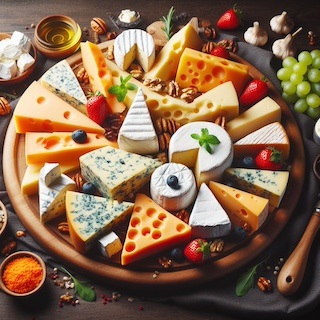

Content credentials Generated with AI ∙ May 20, 2024 at 10:18 PM

> CountVectorizer converts a collection of text documents to a matrix of word counts.

```python
train_df_copy = train_df.copy()
train_df_copy['combined'] = train_df_copy['FlavourEn'].astype(str) + ' ' + train_df_copy['CharacteristicsEn'].astype(str) + ' ' + train_df_copy['CategoryTypeEn'].astype(str) + ' ' + train_df_copy['MilkTypeEn'].astype(str) + ' ' + train_df_copy['RindTypeEn'].astype(str)

cv = CountVectorizer()

vector = cv.fit_transform(train_df_copy['combined'])

combined_df = pd.DataFrame(vector.toarray(), columns=cv.get_feature_names())
combined_df
```

|  | 100 | 16 | 20 | 25 | 41 | 50 | accent | accents | accentuated | accompanied | ... | year | years | yellow | yet | yeux | yogurt | young | younger | your | yr |
| --- | --- | --- | --- | --- | --- | --- | --- | --- | --- | --- | --- | --- | --- | --- | --- | --- | --- | --- | --- | --- | --- |
| 0 | 0 | 0 | 0 | 0 | 0 | 0 | 0 | 0 | 0 | 0 | ... | 0 | 0 | 0 | 0 | 0 | 0 | 0 | 0 | 0 | 0 |
| 1 | 0 | 0 | 0 | 0 | 0 | 0 | 0 | 0 | 0 | 0 | ... | 0 | 0 | 0 | 0 | 0 | 0 | 0 | 0 | 0 | 0 |
| 2 | 0 | 0 | 0 | 0 | 0 | 0 | 0 | 0 | 0 | 0 | ... | 0 | 0 | 0 | 0 | 0 | 0 | 0 | 0 | 0 | 0 |
| 3 | 0 | 0 | 0 | 0 | 0 | 0 | 0 | 0 | 0 | 0 | ... | 0 | 0 | 0 | 0 | 0 | 0 | 0 | 0 | 0 | 0 |
| 4 | 0 | 0 | 0 | 0 | 0 | 0 | 0 | 0 | 0 | 0 | ... | 0 | 0 | 0 | 0 | 0 | 0 | 0 | 0 | 0 | 0 |
| ... | ... | ... | ... | ... | ... | ... | ... | ... | ... | ... | ... | ... | ... | ... | ... | ... | ... | ... | ... | ... | ... |
| 828 | 0 | 0 | 0 | 0 | 0 | 0 | 0 | 0 | 0 | 0 | ... | 0 | 0 | 0 | 0 | 0 | 0 | 0 | 0 | 0 | 0 |
| 829 | 0 | 0 | 0 | 0 | 0 | 0 | 0 | 0 | 0 | 0 | ... | 0 | 0 | 1 | 0 | 0 | 0 | 0 | 0 | 0 | 0 |
| 830 | 0 | 0 | 0 | 0 | 0 | 0 | 0 | 0 | 0 | 0 | ... | 0 | 0 | 0 | 0 | 0 | 0 | 0 | 0 | 0 | 0 |
| 831 | 0 | 0 | 0 | 0 | 0 | 0 | 0 | 0 | 0 | 0 | ... | 0 | 0 | 0 | 0 | 0 | 0 | 0 | 0 | 0 | 0 |
| 832 | 0 | 0 | 0 | 0 | 0 | 0 | 0 | 0 | 0 | 0 | ... | 0 | 0 | 0 | 0 | 0 | 0 | 0 | 0 | 0 | 0 |

833 rows × 806 columns

```python
combined_df.columns
```

```
Index(['100', '16', '20', '25', '41', '50', 'accent', 'accents', 'accentuated',
       'accompanied',
       ...
       'year', 'years', 'yellow', 'yet', 'yeux', 'yogurt', 'young', 'younger',
       'your', 'yr'],
      dtype='object', length=806)
```

```python
train_df_copy = train_df.copy()

train_df_copy['combined'] = train_df_copy['FlavourEn'].astype(str) + ' ' + train_df_copy['CharacteristicsEn'].astype(str) + ' ' + train_df_copy['CategoryTypeEn'].astype(str) + ' ' + train_df_copy['MilkTypeEn'].astype(str) + ' ' + train_df_copy['RindTypeEn'].astype(str)

cv = CountVectorizer()

vector = cv.fit_transform(train_df_copy['combined'])

combined_df = pd.DataFrame(vector.toarray(), columns=cv.get_feature_names())
combined_df
```

|  | 100 | 16 | 20 | 25 | 41 | 50 | accent | accents | accentuated | accompanied | ... | year | years | yellow | yet | yeux | yogurt | young | younger | your | yr |
| --- | --- | --- | --- | --- | --- | --- | --- | --- | --- | --- | --- | --- | --- | --- | --- | --- | --- | --- | --- | --- | --- |
| 0 | 0 | 0 | 0 | 0 | 0 | 0 | 0 | 0 | 0 | 0 | ... | 0 | 0 | 0 | 0 | 0 | 0 | 0 | 0 | 0 | 0 |
| 1 | 0 | 0 | 0 | 0 | 0 | 0 | 0 | 0 | 0 | 0 | ... | 0 | 0 | 0 | 0 | 0 | 0 | 0 | 0 | 0 | 0 |
| 2 | 0 | 0 | 0 | 0 | 0 | 0 | 0 | 0 | 0 | 0 | ... | 0 | 0 | 0 | 0 | 0 | 0 | 0 | 0 | 0 | 0 |
| 3 | 0 | 0 | 0 | 0 | 0 | 0 | 0 | 0 | 0 | 0 | ... | 0 | 0 | 0 | 0 | 0 | 0 | 0 | 0 | 0 | 0 |
| 4 | 0 | 0 | 0 | 0 | 0 | 0 | 0 | 0 | 0 | 0 | ... | 0 | 0 | 0 | 0 | 0 | 0 | 0 | 0 | 0 | 0 |
| ... | ... | ... | ... | ... | ... | ... | ... | ... | ... | ... | ... | ... | ... | ... | ... | ... | ... | ... | ... | ... | ... |
| 828 | 0 | 0 | 0 | 0 | 0 | 0 | 0 | 0 | 0 | 0 | ... | 0 | 0 | 0 | 0 | 0 | 0 | 0 | 0 | 0 | 0 |
| 829 | 0 | 0 | 0 | 0 | 0 | 0 | 0 | 0 | 0 | 0 | ... | 0 | 0 | 1 | 0 | 0 | 0 | 0 | 0 | 0 | 0 |
| 830 | 0 | 0 | 0 | 0 | 0 | 0 | 0 | 0 | 0 | 0 | ... | 0 | 0 | 0 | 0 | 0 | 0 | 0 | 0 | 0 | 0 |
| 831 | 0 | 0 | 0 | 0 | 0 | 0 | 0 | 0 | 0 | 0 | ... | 0 | 0 | 0 | 0 | 0 | 0 | 0 | 0 | 0 | 0 |
| 832 | 0 | 0 | 0 | 0 | 0 | 0 | 0 | 0 | 0 | 0 | ... | 0 | 0 | 0 | 0 | 0 | 0 | 0 | 0 | 0 | 0 |

833 rows × 806 columns

```python
train_df_copy = train_df.copy()

train_df_copy['combined'] = train_df_copy['FlavourEn'].astype(str) + ' ' + train_df_copy['CharacteristicsEn'].astype(str) + ' ' + train_df_copy['CategoryTypeEn'].astype(str) + ' ' + train_df_copy['MilkTypeEn'].astype(str) + ' ' + train_df_copy['RindTypeEn'].astype(str)

cv = CountVectorizer()

vector = cv.fit_transform(train_df_copy['combined'])

combined_df = pd.DataFrame(vector.toarray(), columns=cv.get_feature_names())
combined_df
```

|  | 100 | 16 | 20 | 25 | 41 | 50 | accent | accents | accentuated | accompanied | ... | year | years | yellow | yet | yeux | yogurt | young | younger | your | yr |
| --- | --- | --- | --- | --- | --- | --- | --- | --- | --- | --- | --- | --- | --- | --- | --- | --- | --- | --- | --- | --- | --- |
| 0 | 0 | 0 | 0 | 0 | 0 | 0 | 0 | 0 | 0 | 0 | ... | 0 | 0 | 0 | 0 | 0 | 0 | 0 | 0 | 0 | 0 |
| 1 | 0 | 0 | 0 | 0 | 0 | 0 | 0 | 0 | 0 | 0 | ... | 0 | 0 | 0 | 0 | 0 | 0 | 0 | 0 | 0 | 0 |
| 2 | 0 | 0 | 0 | 0 | 0 | 0 | 0 | 0 | 0 | 0 | ... | 0 | 0 | 0 | 0 | 0 | 0 | 0 | 0 | 0 | 0 |
| 3 | 0 | 0 | 0 | 0 | 0 | 0 | 0 | 0 | 0 | 0 | ... | 0 | 0 | 0 | 0 | 0 | 0 | 0 | 0 | 0 | 0 |
| 4 | 0 | 0 | 0 | 0 | 0 | 0 | 0 | 0 | 0 | 0 | ... | 0 | 0 | 0 | 0 | 0 | 0 | 0 | 0 | 0 | 0 |
| ... | ... | ... | ... | ... | ... | ... | ... | ... | ... | ... | ... | ... | ... | ... | ... | ... | ... | ... | ... | ... | ... |
| 828 | 0 | 0 | 0 | 0 | 0 | 0 | 0 | 0 | 0 | 0 | ... | 0 | 0 | 0 | 0 | 0 | 0 | 0 | 0 | 0 | 0 |
| 829 | 0 | 0 | 0 | 0 | 0 | 0 | 0 | 0 | 0 | 0 | ... | 0 | 0 | 1 | 0 | 0 | 0 | 0 | 0 | 0 | 0 |
| 830 | 0 | 0 | 0 | 0 | 0 | 0 | 0 | 0 | 0 | 0 | ... | 0 | 0 | 0 | 0 | 0 | 0 | 0 | 0 | 0 | 0 |
| 831 | 0 | 0 | 0 | 0 | 0 | 0 | 0 | 0 | 0 | 0 | ... | 0 | 0 | 0 | 0 | 0 | 0 | 0 | 0 | 0 | 0 |
| 832 | 0 | 0 | 0 | 0 | 0 | 0 | 0 | 0 | 0 | 0 | ... | 0 | 0 | 0 | 0 | 0 | 0 | 0 | 0 | 0 | 0 |

833 rows × 806 columns

```python
train_df_copy = train_df.copy()
train_df_copy['CheeseName'] = train_df_copy['CheeseName'].fillna(0)

vectorizer = CountVectorizer()

X_counts = vectorizer.fit_transform(train_df_copy['CheeseName'])

name_df = pd.DataFrame(X_counts.toarray(), columns=vectorizer.get_feature_names(), index=train_df_copy.index)
name_df
```

|  | 115e | 12 | 14 | 15 | 1608 | 1860 | 1ière | 20 | 2ième | 3ième | ... | élan | élisabeth | élite | émile | érable | érables | étoile | évanjules | île | îles |
| --- | --- | --- | --- | --- | --- | --- | --- | --- | --- | --- | --- | --- | --- | --- | --- | --- | --- | --- | --- | --- | --- |
| 980 | 0 | 0 | 0 | 0 | 0 | 0 | 0 | 0 | 0 | 0 | ... | 0 | 0 | 0 | 0 | 0 | 0 | 0 | 0 | 0 | 0 |
| 361 | 0 | 0 | 0 | 0 | 0 | 0 | 0 | 0 | 0 | 0 | ... | 0 | 0 | 0 | 0 | 0 | 0 | 0 | 0 | 0 | 0 |
| 130 | 0 | 0 | 0 | 0 | 0 | 0 | 0 | 0 | 0 | 0 | ... | 0 | 0 | 0 | 0 | 0 | 0 | 0 | 0 | 0 | 0 |
| 119 | 0 | 0 | 0 | 0 | 0 | 0 | 0 | 0 | 0 | 0 | ... | 0 | 0 | 0 | 0 | 0 | 0 | 0 | 0 | 0 | 0 |
| 374 | 0 | 0 | 0 | 0 | 0 | 0 | 0 | 0 | 0 | 0 | ... | 0 | 0 | 0 | 0 | 0 | 0 | 0 | 0 | 0 | 0 |
| ... | ... | ... | ... | ... | ... | ... | ... | ... | ... | ... | ... | ... | ... | ... | ... | ... | ... | ... | ... | ... | ... |
| 118 | 0 | 0 | 0 | 0 | 0 | 0 | 0 | 0 | 0 | 0 | ... | 0 | 0 | 0 | 0 | 0 | 0 | 0 | 0 | 0 | 0 |
| 681 | 0 | 0 | 0 | 0 | 0 | 0 | 0 | 0 | 0 | 0 | ... | 0 | 0 | 0 | 0 | 0 | 0 | 0 | 0 | 0 | 0 |
| 86 | 0 | 0 | 0 | 0 | 0 | 0 | 0 | 0 | 0 | 0 | ... | 0 | 0 | 0 | 0 | 0 | 0 | 0 | 0 | 0 | 0 |
| 724 | 0 | 0 | 0 | 0 | 0 | 0 | 0 | 0 | 0 | 0 | ... | 0 | 0 | 0 | 0 | 0 | 0 | 0 | 0 | 0 | 0 |
| 876 | 0 | 0 | 0 | 0 | 0 | 0 | 0 | 0 | 0 | 0 | ... | 0 | 0 | 0 | 0 | 0 | 0 | 0 | 0 | 0 | 0 |

833 rows × 887 columns

```python
X = combined_df
y = name_df

X_train, X_test, y_train, y_test = train_test_split(X, y, test_size=0.2, random_state=333)

dummy = DummyRegressor(strategy="mean")
dummy.fit(X_train, y_train);
cv_results = cross_validate(dummy, X_train, y_train, return_train_score=True)
pd.DataFrame(cv_results).mean()
```

```
fit_time       0.024334
score_time     0.012696
test_score     0.141416
train_score    0.268546
dtype: float64
```

```python
rf = RandomForestRegressor(n_estimators=100, random_state=333)

rf.fit(X_train, y_train)

cv_results_rf = cross_validate(rf, X_train, y_train, return_train_score=True)
pd.DataFrame(cv_results_rf).mean()
```

```
fit_time       27.335436
score_time      0.058116
test_score      0.156343
train_score     0.830618
dtype: float64
```

```python
pipe = Pipeline(
            steps=[("imputer", SimpleImputer(strategy="median")),
                   ("scaler", StandardScaler()),
                   ("knn", KNeighborsRegressor())]
)
```

```python
param_grid = {
    "knn__n_neighbors" : [1, 5, 10, 20, 30, 40, 50],
    "knn__weights" : ['uniform', 'distance']
}
```

```python
grid_search = GridSearchCV(pipe, param_grid, cv=5, verbose=1, n_jobs=-1)
grid_search.fit(X_train, y_train)
```

```
Fitting 5 folds for each of 14 candidates, totalling 70 fits
```

```
GridSearchCV(cv=5,
             estimator=Pipeline(steps=[('imputer',
                                        SimpleImputer(strategy='median')),
                                       ('scaler', StandardScaler()),
                                       ('knn', KNeighborsRegressor())]),
             n_jobs=-1,
             param_grid={'knn__n_neighbors': [1, 5, 10, 20, 30, 40, 50],
                         'knn__weights': ['uniform', 'distance']},
             verbose=1)
```

```python
best_hyperparams = grid_search.best_params_
print(best_hyperparams)

best_score = grid_search.best_score_
print(best_score)
```

```
{'knn__n_neighbors': 1, 'knn__weights': 'uniform'}
0.5381757088249467
```

```python
test_score = grid_search.score(X_test, y_test)
test_score
```

```
0.4562198860155578
```

#### **Discussion**

- Concluding remarks
  - Interpret results in the context of project's goals.

    I have successfully improved the model, which accurately predicts whether a cheese product has a higher or lower fat content based on the given data. The overall accuracy of the model RandomForestClassifier is 0.84. This suggests that the model has a relatively good performance.
  - Relate the findings back to the initial problem statement.

    The model performance aligns with our project objectives, demonstrating accurate predictions of fat levels.
  - If your model provides feature importance scores, present and discuss them. Explain which features had the most influence on predictions.

    ```
      Feature ranking:
      1. feature 0 (0.514878)
      2. feature 1 (0.005168)
      3. feature 2 (0.014288)
      4. feature 3 (0.004052)
      5. feature 4 (0.004764)
      6. feature 5 (0.004204)
      7. feature 6 (0.016653)

      Index(['ManufacturerProvCode', 'ManufacturingTypeEn', 'MoisturePercent',
     'Organic', 'CategoryTypeEn', 'MilkTypeEn', 'MilkTreatmentTypeEn'],
      dtype='object')
    ```

    Identifying the optimal model presents a significant challenge and comes with limitations. The official scikit-learn website also acknowledges this fact, e.g., "tough luck", "😭".

[figure not shown]

  [scikit-learn algorithm cheat sheet](https://scikit-learn.org/stable/tutorial/machine_learning_map/)
  - Discuss potential sources of bias, data quality issues, or other factors that might affect the results.

    As a beginner, my expertise is still developing. Therefore, there is ample room for growth and learning to gain deeper insights.

#### References

I want to clarify that my main reference when working on this project was all the learning materials provided in this program. My goal was to meet the requirements and also learn how to properly document and present my work. As a result, there may be similarities in the presentation.

I need to clarify that some of the content in this notebook is not original. I have borrowed certain parts from online resources. I have utilized Microsoft Bing AI as a valuable tool for brainstorming and gathering resources. I have also used Grammarly to improve my writing.

##### Main Resources I used

- [Introduction to Machine Learning](https://ml-learn.mds.ubc.ca/en/) The course videos and slides
- [scikit-learn](https://scikit-learn.org/stable/index.html)  
  Pedregosa, F., Varoquaux, Ga"el, Gramfort, A., Michel, V., Thirion, B., Grisel, O., … others. (2011). Scikit-learn: Machine learning in Python. Journal of Machine Learning Research, 12(Oct), 2825–2830.
- [Python 3](https://www.python.org/)  
  Van Rossum, G., & Drake, F. L. (2009). Python 3 Reference Manual. Scotts Valley, CA: CreateSpace.
- [NumPy](https://numpy.org/)  
  Harris, C. R., Millman, K. J., van der Walt, S. J., Gommers, R., Virtanen, P., Cournapeau, D., … Oliphant, T. E. (2020). Array programming with NumPy. Nature, 585, 357–362. https://doi.org/10.1038/s41586-020-2649-2
- [Pandas](https://pandas.pydata.org/docs/#pandas-documentation)  
  McKinney, W., & others. (2010). Data structures for statistical computing in python. In Proceedings of the 9th Python in Science Conference (Vol. 445, pp. 51–56).
- [Jupyter Notebook](https://jupyter.org/)  
  Kluyver, T., Ragan-Kelley, B., Fernando P'erez, Granger, B., Bussonnier, M., Frederic, J., … Willing, C. (2016). Jupyter Notebooks – a publishing format for reproducible computational workflows. In F. Loizides & B. Schmidt (Eds.), Positioning and Power in Academic Publishing: Players, Agents and Agendas (pp. 87–90).
- [Vega-Altair](https://altair-viz.github.io/index.html#)  
  VanderPlas, J., Granger, B., Heer, J., Moritz, D., Wongsuphasawat, K., Satyanarayan, A., … Sievert, S. (2018). Altair: Interactive statistical visualizations for python. Journal of Open Source Software, 3(32), 1057.
- [Stack Overflow](https://stackoverflow.com/)  
  Stack overflow. (2008). Retrieved from https://stackoverflow.com/